# Dev_between_sensors

Flueckiger_Rubens

2025-04-01

# 1 Deviation between Sensors

In this file differences between a reference sensor to the others are visualised Here I took Sensor_3 (3m above ground) as reference Sensor. The choice roots from measurement conventions for devices at this height. Additionally, Bias-correction was performed at the same height, whereas a cross-validation between all sensors where not performed.

*Note:* Due to the moist adiabatic lapse rate being at T<sub>s</sub> = 0.0069 K/m (for T = 273.2K or 0°C) and T<sub>s</sub> = 0.0036K/m (for T = 303K or 29.8°C) [Pal, 2001, P.68], the decrease in Temperature is negligible (in our case: 3m $*$ 0.0036K/m = 0.0108K decrease) and high degree differences (might) only occur due to device inaccuracy/bias.

Arya, S. Pal (2001), Introduction to Micrometeorology.Vereinigtes Königreich,Elsevier Science,2001.

# 2 Import packages and file

```r
#Packages
library(dplyr)
library(ggplot2)

#File
lap <- read.table("../data/Distanz_&_Hohe_GR.csv", sep = ";", header = T)
```

# 3 New dataset

# 4 Plotting

color codes

Temperature

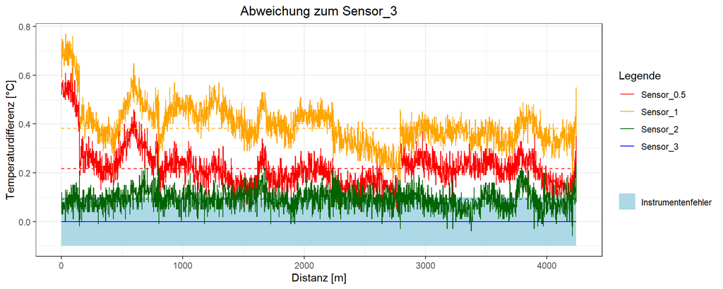

Fig. 1: Deviation to Sensor_3 for temperature

Relative air humidity

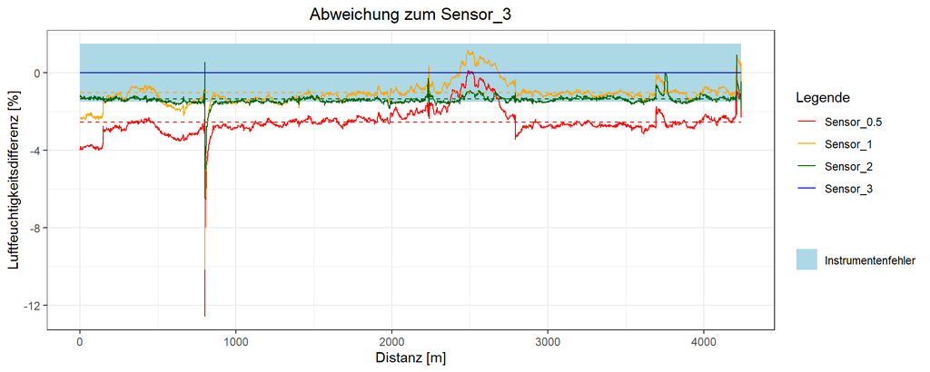

Fig. 2: Deviation to Sensor_3 for humidity

# 4 Statistics

Temperaturstatistik

[output not shown]

Luftfeuchtigkeitsstatistik

[output not shown]